# tarea1_idg_salas

mathias salas

2025-04-21

# Introducción

El presente análisis utiliza los datos de la Encuesta CASEN 2022 para estudiar los factores que influyen en el ingreso per cápita de la población ocupada en Chile. El ingreso es una variable clave para evaluar la desigualdad y las condiciones socioeconómicas de los hogares, por lo que entender sus determinantes resulta fundamental para la formulación de políticas públicas.

A partir de un modelo de regresión lineal, se incorporan variables individuales como el sexo, el nivel educativo, la edad y la rama económica en la que trabaja la persona encuestada. Además, se exploran visualizaciones y diagnósticos para evaluar el comportamiento del modelo y la distribución del ingreso.

# Objetivos

- Analizar la distribución del ingreso per cápita en la población ocupada.
- Identificar qué variables explican en mayor medida las diferencias de ingreso.
- Evaluar la relación entre ingreso y características individuales como sexo, educación y edad.
- Incorporar la variable `rama1` para representar la actividad económica del lugar de trabajo.
- Ajustar y evaluar un modelo de regresión lineal que explique el ingreso per cápita.
- Comparar visualmente los ingresos entre grupos (por sexo y educación).

# Procesamiento de datos

en primer lugar, se instalan los paquetes necesarios y librerias necesarias para que el codigo pueda ejecutarse

```r
library(here)
library(haven)
library(car)
library(broom)
library(ggplot2)
casen_rm <- readRDS(here("data", "casen_rm.rds"))
```

# Metodología

El análisis se desarrolló utilizando la base de datos de la Encuesta CASEN 2022, la cual contiene información socioeconómica de los hogares en Chile. Para este estudio, se trabajó exclusivamente con personas ocupadas, filtrando aquellos registros con ingresos per cápita válidos (es decir, mayores a cero y sin valores perdidos).

- **Sexo:** variable categórica que distingue entre hombres y mujeres.
- **Nivel educativo:** nivel de instrucción alcanzado por la persona.
- **Edad:** variable continua.
- **Rama económica (`rama1`):** sector económico donde se desempeña la persona.

Estas variables fueron transformadas a formato factor cuando correspondía, para su correcta interpretación dentro del modelo de regresión lineal. Posteriormente, se ajustó el modelo lineal simple con ingreso per cápita como variable dependiente, y se evaluaron los coeficientes, significancia estadística, diagnóstico de residuos, colinealidad y capacidad explicativa mediante el coeficiente de determinación (R²).

Además, se generaron gráficos descriptivos complementarios para visualizar las diferencias de ingreso entre grupos por sexo y educación.

## Primer vistazo a base de datos

se realiza un histograma y boxplot a la base de datos original, sin ningun tipo de modificacion, para una visualizacion

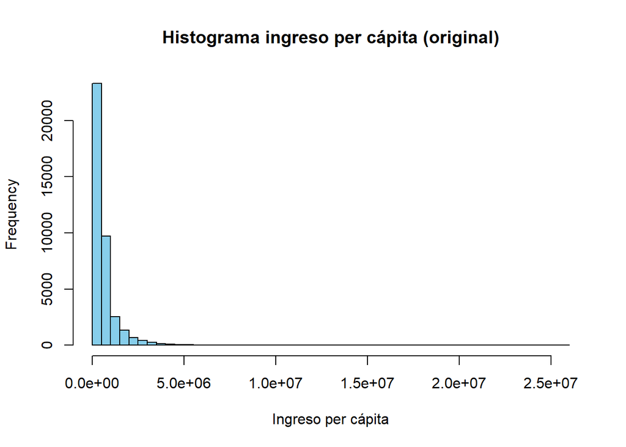

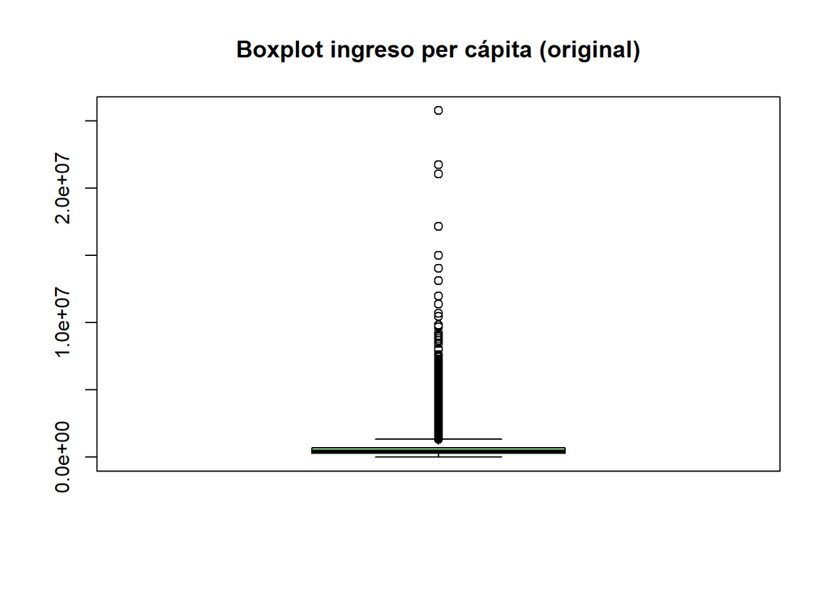

## Limpieza de datos

Es necesario realizar una limpieza a la base de datos, eliminando todo registro vacio o con NA´s, evitando problemas futuros

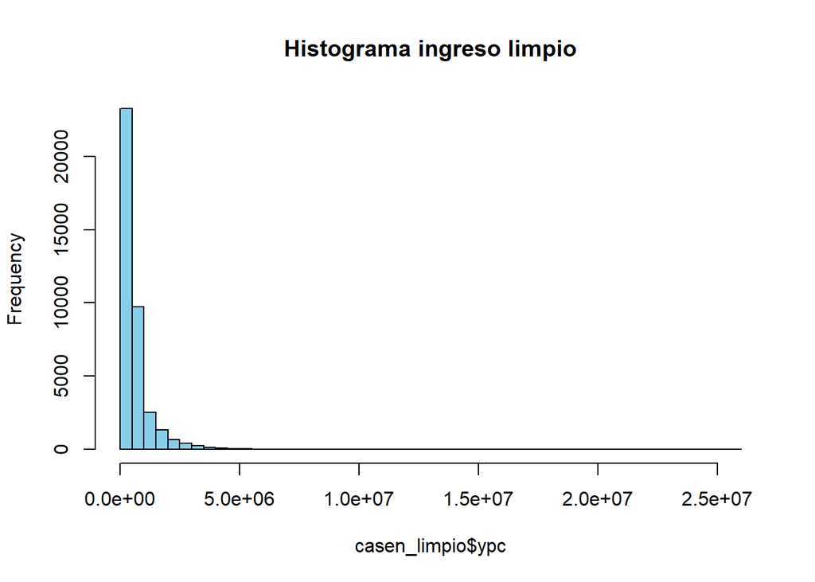

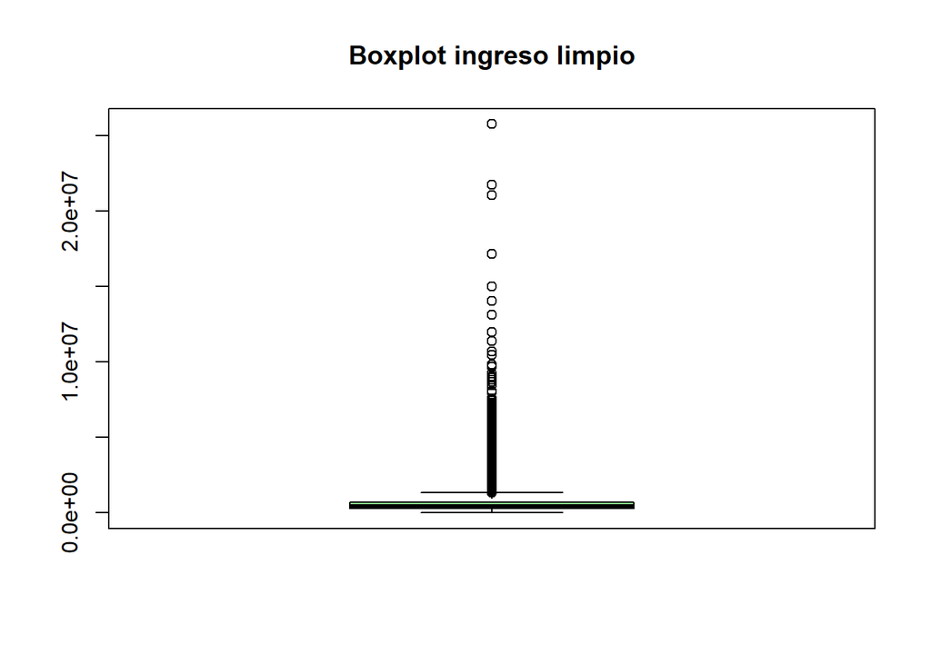

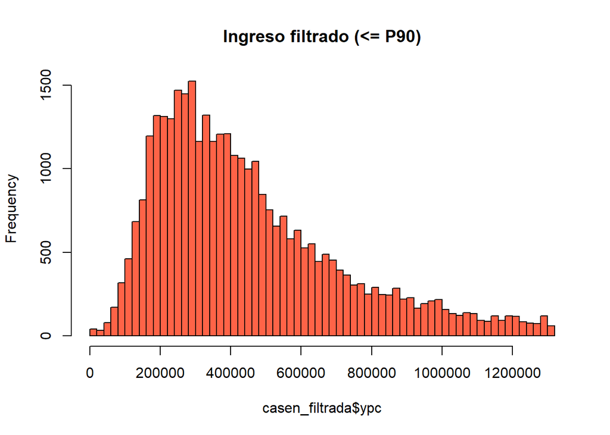

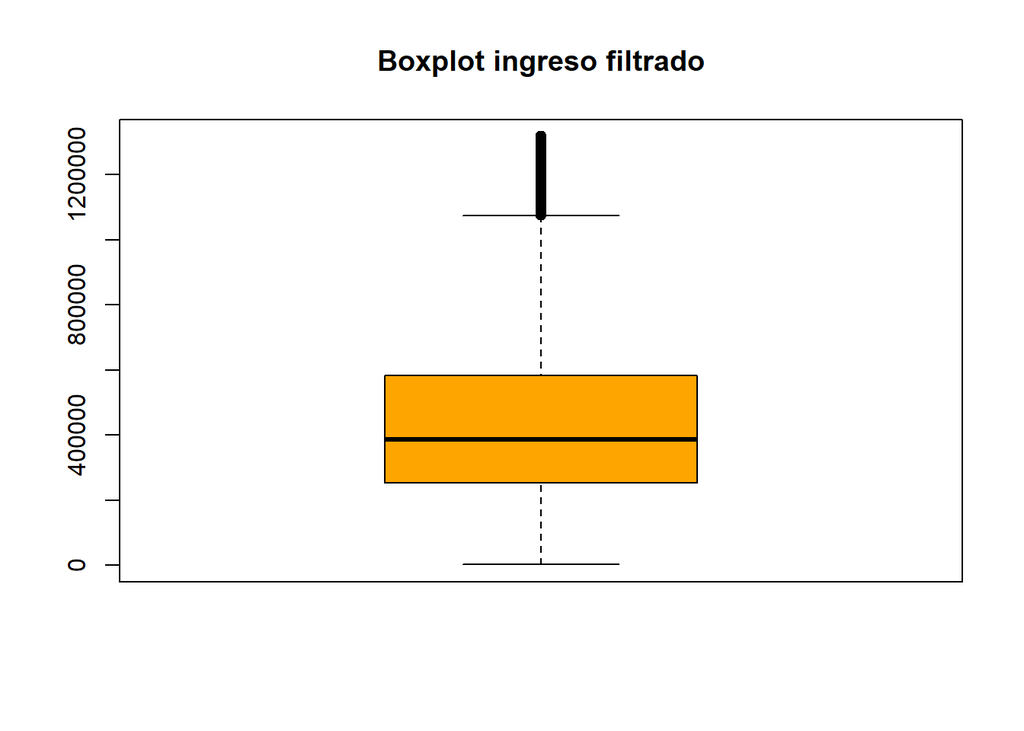

Luego de la limpieza, y filtrado por el 90% de los datos, se observa en los graficos, que ahora el histograma del ingreso per capita, sigue una distribucion algo mas “normal” aunque sigue teniendo un sesgo a los ingresos mas bajos, tambien en el boxplot, se eliminaron muchos outliers, pero sigue habiendo algunos, se prefirio continuar con este filtrado, ya que un filtro mas fuerte, del 80%, eliminaria muchos datos, haciendo que la muestra no sea tan representativa para el objetivo del estudio

## Se realiza una pequeña visualizacion de dos de las variables explicativas, como lo son la educacion y el sexo

```
## 1. Hombre  2. Mujer
##     16249     18447
```

```
##                              No sabe                 Sin educación formal
##                                  230                                 2935
##                    Básica incompleta                      Básica completa
##                                 5868                                 2722
##           Media humanista incompleta Media técnica profesional incompleta
##                                 3604                                  984
##             Media humanista completa   Media técnica profesional completa
##                                 6178                                 2644
##    Técnico nivel superior incompleta      Técnico nivel superior completo
##                                 1020                                 2166
##               Profesional incompleto                  Posgrado incompleto
##                                 2588                                   99
##                 Profesional completo                    Posgrado completo
##                                 3393                                  265
```

## Residuos y heterocedasticidad

en estos graficos, se observa como se comportan las pruebas estadisticas para determinar problemas como heterocedasticidad.

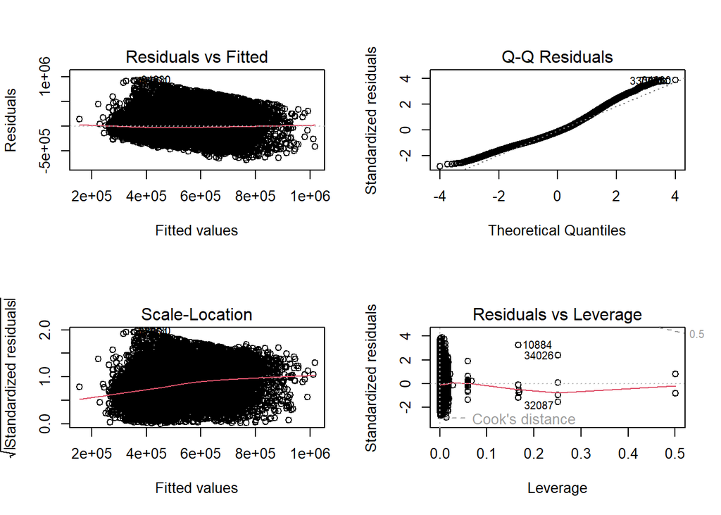

## Analisis de R2, VIF Y ANOVA como medida de ajuste

Para determinar si el modelo resulta concluyente o no, se utilizara como medida base el R2, el cual nos indicara que tan bien se ajusta el modelo para predecir el ingreso per capita, tambien agregado a esto, se muestran los resultados del Vif y el test ANOVA para todo el modelo.

[output not shown]

```r
vif(modelo)
```

```
##           GVIF Df GVIF^(1/(2*Df))
## sexo  1.226025  1        1.107260
## educ  1.572425 13        1.017561
## edad  1.209204  1        1.099638
## rama1 1.678478 23        1.011322
```

```r
anova(modelo)
```

```
## Analysis of Variance Table
##
## Response: ypc
##              Df     Sum Sq    Mean Sq  F value Pr(>F)
## sexo          1 1.6548e+10 1.6548e+10   0.2816 0.5957
## educ         13 1.9716e+14 1.5166e+13 258.0755 <2e-16 ***
## edad          1 3.6435e+13 3.6435e+13 620.0074 <2e-16 ***
## rama1        23 1.5400e+13 6.6958e+11  11.3943 <2e-16 ***
## Residuals 15714 9.2343e+14 5.8765e+10
## ---
## Signif. codes:  0 '***' 0.001 '**' 0.01 '*' 0.05 '.' 0.1 ' ' 1
```

El VIF mide la colinealidad entre los predictores de tu modelo. En este caso: Las variables sexo, educ, edad y rama1 tienen valores de GVIF relativamente bajos (alrededor de 1). Esto indica que no hay una multicolinealidad severa entre los predictores.

## TEST ANOVA

sobre el test anova, es necesario resaltar unicamente, que todas las variables predictoras cuentan con un p valor bajo, lo cual indica que son fuertemente significativas en la prediccion del ingreso sin embargo, solo la variable sexo tiene un p valor bastante alto (0.5957), lo que indica que no es un predictor significativo para explicar la variación en los ingresos. .

## GRAFICOS POR VARIABLE EXPLICATIVA

### Sexo y educacion

Por ultimo, se realizaron graficos de las variables anteriormente mencionadas, para obtener una visualizacion clara de que tan importante es cada una por separado, en la prediccion del ingreso.

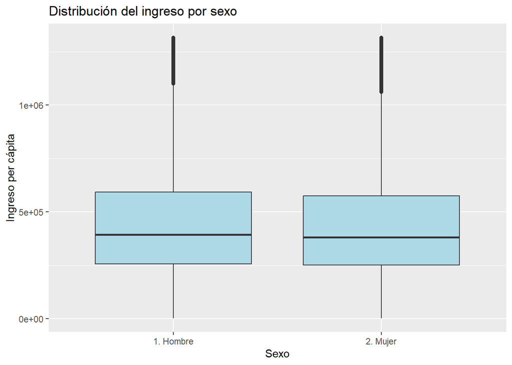

Como se observa en el boxplot de la variable sexo, no existe realmente una diferencia muy significativa, lo que refuerza la hipotesis de que el sexo no es una variable con tanta relevancia a la hora de, almenos predecir el ingreso per capita

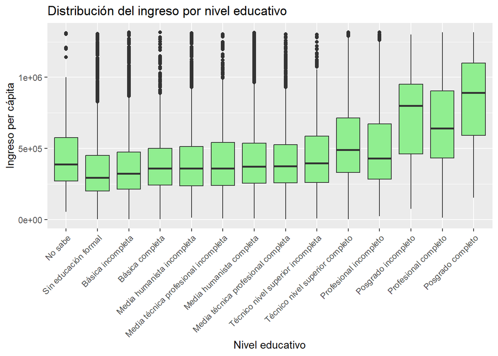

En el ultimo grafico, se observa una clara tendencia al aumento del ingreso mientras mayor nivel educativo se posee, es decir, la mediana del ingreso generalmente aumenta con el nivel educativo, indicando que a mayor educación, el ingreso tiende a ser más alto. por ejemplo, aquellos que solo tienen un nivel educativo de enseñanza basica incompleta, generan menos ingresos que los ultimos escalones de educacion, como lo son universitario profesional o posgrado completo.

# Conclusión

El modelo de regresión ajustado permitió identificar algunas variables con influencia significativa sobre el ingreso per cápita de las personas ocupadas en Chile. Entre estas, destacan el nivel educativo y la rama económica en que trabaja la persona, lo que confirma que tanto la formación académica como el sector productivo son factores clave en las diferencias de ingresos.